# Difference measurement

Quentin Dénigot

12 mars 2021

## Intro

Heather proposed a nice and simple method for a difference measurement that makes sense earlier this week, this document is the explanation of that method as well as its tentative implementation (proper implementation and iteration over all relevant words will be done by the corresponding `diff_measure.R` script).

## Past attempts

As a reminder, I have already tried two methods of difference measurement that mostly failed:

- Cardinality of the set-intersection
- Spearman’s rho

What difference are we measuring? One key aspect of our analysis is that we predict that words are used differently by different social groups. We tried to see if word embeddings could capture such difference. Because of the stochastic aspect of these methods and the relatively small size of our corpora, a difference was bound to be observed, what remained was to see whether that difference was important enough to comment upon. All the details of the study are in the corresponding paper.

A first approach was to try and quantify that difference. To do so, we took the 12 most similar words to each of our words of interest in each of our corpora; for each word of interest we end up with two lists, one of most similar words in the “pro” corpus, and another one in the “anti” corpus. First attempt was simply to count how many words from list 1 were not in list 2. This is very limited, notably because the 12 word limit was chosen completely arbitrarily (if we made that number big enough, surely we would not see any difference between the lists) but it had the advantage of being super simple and make very easy predictions: for our test words (where we expect some change across communities), the count should be big, and for our control words (where we expect little to no difference), the count should be small.

It turned out not to work as well as anticipated, and there was no clear cut conclusion to be derived from this. We therefore turned to another measure for difference and tried Spearman’s rho. Spearman’s rho gives a measure of the difference in ordering of two lists of numbers (importantly, those lists should contain the exact same numbers). First, we restricted the analysis to the intersection of the two vocabularies of our models (which is in itself not satisfactory), then we took the vocabulary of corpus 1, gave a unique number to each word, kept that pairing, applied to to corpus 2 and compared it using Spearman’s rho. In that case, it turned out that there was still too much variation to make anything out of it, control words did not appear to have more similar lists of most similar words. But many things could explain it.

## New method

This new method is pretty simple and stemmed from one observation : although it was not possible to quantify the observed difference between control words across corpora vs test words and arrive at meaningful conclusions, a brief qualitative analysis of the lists of most similar words still showed promise: the words most similar to our test words seemed a lot ‘more’ different than for the control words in the sense that all the most similar words for the control words were ‘expected’.

Is there a way we can quantify this ‘unexpectedness’ and use the measure as a basis for our analysis?

We propose:

Given a word of interest *w*, we can generate one list of most similar words per corpus, which we will call *list_a* and *list_b*. These lists are likely to be different in their orderings. Limiting ourselves to the top 12 most similar words, we can take the words that appear in *list_a* but do not appear in *list_b* and check their similarity **rankings** in corpus *b*.

What we predict:

- We should observe that in average these rankings are *lower* for our control words and *higher* for our test words.
- The measure is asymmetrical. We can therefore have three outcomes :
  1. The ‘missing words’ from *list_a* and *list_b* both present similar rankings, these rankings are in average *low* and not very spread-out: this means that the words are used very similarly in both corpora.
  2. The ‘missing words’ from *list_a* and *list_b* both present similar rankings, these rankings are in average *high* and not very spread-out: this means that the words are used very dissimilarly in both corpora. **Note**: If the rankings are in fact very spread out, it might be an indication that a few of the ‘missing words’ are out of place, we will categorize these as belonging to the second case.
  3. The ‘missing words’ from *list_a* and *list_b* present dissimilar rankings, these rankings are in average *low* for one and *high* for the other. This means that the set of uses of one word across corpora differs; specifically, the uses of one word in one corpus is a strict subset of the uses of that word in the other corpus. **This could indicate that something dogwhistley is going on**.

## Implementation

We will try to implement this on two words, one control and one test, in this document (for the full implementation/results, see the full program `diff_measure.R`). The words in question will be *amendement* for the control words and *famille* for the test words.

Note that this explanatory document does not give any kind of final answer, these words were chosen at random, maybe the measurement won’t work on them, what we want to see is whether there is a tendency on the entire group of test words vs control words.

### Loading data

```r
#LOAD DATA
anti_amendement.df <- read.csv("../data/anti/SANITY/amendement_stats.csv", header = TRUE)
anti_famille.df <- read.csv("../data/anti/TEST/famille_stats.csv", header = TRUE)

pro_amendement.df <- read.csv("../data/pro/SANITY/amendement_stats.csv", header = TRUE)
pro_famille.df <- read.csv("../data/pro/TEST/famille_stats.csv", header = TRUE)
```

### Data cleaning

What we need to do now is sort the data to effectively have a list of ‘most similar words’. We sort it by decreasing means. We also get rid of the first row of the dataframe because it corresponds to the word of interest (WOI) (eg. for ‘amendement’, the most similar word is ‘amendement’ with a similarity of 1).

```r
#Sort the data using the mean to recreate the list of most similar words,
#we also get rid of the first entry; which is the word itself
#anti
anti_amendement.df <- anti_amendement.df[order(-anti_amendement.df$mean), , drop = FALSE]
anti_amendement.df <- anti_amendement.df[-1,]
anti_famille.df <- anti_famille.df[order(-anti_famille.df$mean), , drop = FALSE]
anti_famille.df <- anti_famille.df[-1,]

#pro
pro_amendement.df <- pro_amendement.df[order(-pro_amendement.df$mean), , drop = FALSE]
pro_amendement.df <- pro_amendement.df[-1,]
pro_famille.df <- pro_famille.df[order(-pro_famille.df$mean), , drop = FALSE]
pro_famille.df <- pro_famille.df[-1,]
```

We then take our 12 most similar words in each table. Once that is done, we can compare them using a function that does what was described above: it takes two lists of words, compares them, and returns the average ranking in corpus *b* of the words from *list_a* that were not present in *list_b*.

```r
#anti
anti_amendement_most_similar_words <- anti_amendement.df$X[1:12]
anti_famille_most_similar_words <- anti_famille.df$X[1:12]

#pro
pro_amendement_most_similar_words <- pro_amendement.df$X[1:12]
pro_famille_most_similar_words <- pro_famille.df$X[1:12]

find_rank <- function(missing_word, df){
  rank <- which(missing_word == df$X)
  return(rank[1])
}

compare_ranks <- function(list_a, list_b, df_b){
  missing_words <- unique(list_a[! list_a %in% list_b])
  ranks_in_b <- unlist(lapply(missing_words, FUN=find_rank, df=df_b))
  avg_rank <- sum(as.vector(ranks_in_b))/length(missing_words)
  return(avg_rank)
}
```

### Comparison

First, we’ll check it one way round: we look the difference between pro and anti by taking the pro_df as reference. This means that we check, for each word that is in the *anti* list of most similar words to our WOI but is not in the *pro* list of similar words, its average ranking the *pro* similarity ranking to our WOI.

```r
comparison_amendement_anti_pro <- compare_ranks(anti_amendement_most_similar_words,
                                                pro_amendement_most_similar_words,
                                                pro_amendement.df)

comparison_famille_anti_pro <- compare_ranks(anti_famille_most_similar_words,
                                                pro_famille_most_similar_words,
                                                pro_famille.df)

print(comparison_amendement_anti_pro)
```

```
## [1] 28.57143
```

```r
print(comparison_famille_anti_pro)
```

```
## [1] 57.75
```

Looks like the difference is not so small!

Let’s try the other way round:

```r
comparison_amendement_pro_anti <- compare_ranks(pro_amendement_most_similar_words,
                                                anti_amendement_most_similar_words,
                                                anti_amendement.df)

comparison_famille_pro_anti <- compare_ranks(pro_famille_most_similar_words,
                                                anti_famille_most_similar_words,
                                                anti_famille.df)

print(comparison_amendement_pro_anti)
```

```
## [1] 119.1429
```

```r
print(comparison_famille_pro_anti)
```

```
## [1] 48.625
```

Whoops, it doesn’t seem to work that well anymore. What is this? We were expecting that the numbers for amendement would be smaller because the list of most similar words didn’t look as interesting, but maybe we were wrong, it turns out that maybe the pros use amendement in a very different way! Or maybe there’s an outlier! Given that amendements often appear with proper names, this is very possible, we’ll have to look in more detail, let’s print the rankings for each missing word and see:

```r
missing_words <- unique(anti_amendement_most_similar_words[! anti_amendement_most_similar_words %in% pro_amendement_most_similar_words])
print(missing_words)
```

```
## [1] "articler"    "amendements" "alinéa"      "argument"    "motion"
## [6] "précision"   "initiative"
```

```r
print(unlist(lapply(missing_words, find_rank, df=pro_amendement.df)))
```

```
## [1] 56 17 16 31 30 14 36
```

```r
missing_words <- unique(pro_amendement_most_similar_words[! pro_amendement_most_similar_words %in% anti_amendement_most_similar_words])
print(missing_words)
```

```
## [1] "dispositif"  "amender"     "rapporteur"  "rectifié"    "disposition"
## [6] "accord"      "procaccia"
```

```r
print(unlist(lapply(missing_words, find_rank, df=anti_amendement.df)))
```

```
## [1]  16  38  34  92  14 569  71
```

For the sake of comparison, however, let’s do an equivalent thing to ‘famille’ first:

```r
missing_words <- unique(anti_famille_most_similar_words[! anti_famille_most_similar_words %in% pro_famille_most_similar_words])
print(missing_words)
```

```
## [1] "société"    "filiation"  "vie"        "mère"       "parentèle"
## [6] "justice"    "solidarité" "population"
```

```r
print(unlist(lapply(missing_words, find_rank, df=pro_famille.df)))
```

```
## [1]  44  45  13  20  37 190  88  25
```

```r
missing_words <- unique(pro_famille_most_similar_words[! pro_famille_most_similar_words %in% anti_famille_most_similar_words])
print(missing_words)
```

```
## [1] "enfant"       "fratrie"      "parent"       "situation"    "conjugalité"
## [6] "difficulté"   "endogamie"    "déracinement"
```

```r
print(unlist(lapply(missing_words, find_rank, df=anti_famille.df)))
```

```
## [1]  15  30  73  29  16 102  79  45
```

### Checking cosine similarities

How do we do that? The easiest way to see it is probably a plot, but given that we want to go pretty far in the ranking, it might not actually be very legible. Let’s still try it, first with a look at amendement.

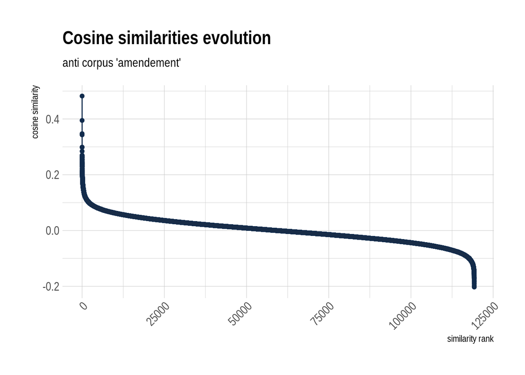

```r
# Make cosine similarity plot : amendement.

#anti
df <- anti_amendement.df
df$X <- factor(df$X, levels = df$X[order(-df$mean)])
df <- df %>%
  mutate(simranks = 1:n())

# The blue from the LLF logo, which we used for the antis
# in the paper
LLF_Blue <- "#112b4c"

anti_amendement_cosine.plot <- ggplot(df, aes(x=simranks, y=mean)) +
  geom_point(color = LLF_Blue) +
  geom_line(aes(x = simranks, y = mean), color = LLF_Blue) +
  geom_ribbon(aes(ymin=ci95_lo, ymax=ci95_hi), alpha = 0.2) +
  labs(title = "Cosine similarities evolution",
       subtitle = "anti corpus 'amendement'",
       x = "similarity rank",
       y = "cosine similarity") +
  theme_ipsum() +

  theme(axis.text.x = element_text(angle = 45, hjust = 1, vjust = 1))

anti_amendement_cosine.plot
```

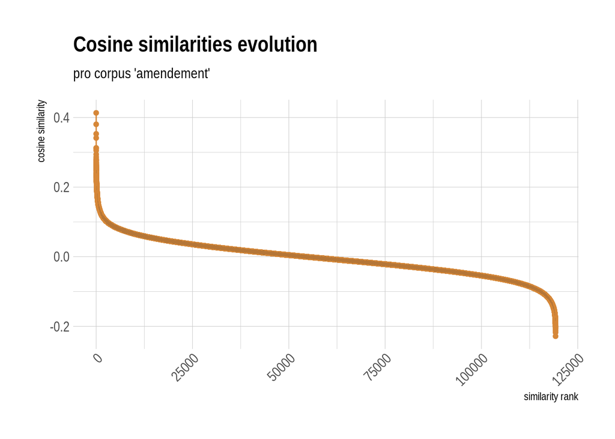

```r
#pro
df <- pro_amendement.df
df$X <- factor(df$X, levels = df$X[order(-df$mean)])
df <- df %>%
  mutate(simranks = 1:n())

# The yellow from the LLF logo, which we used for the pros
# in the paper
LLF_Yellow <- "#d68738"

pro_amendement_cosine.plot <- ggplot(df, aes(x=simranks, y=mean)) +
  geom_point(color = LLF_Yellow) +
  geom_line(aes(x = simranks, y = mean), color = LLF_Yellow) +
  geom_ribbon(aes(ymin=ci95_lo, ymax=ci95_hi), alpha = 0.2) +
  labs(title = "Cosine similarities evolution",
       subtitle = "pro corpus 'amendement'",
       x = "similarity rank",
       y = "cosine similarity") +
  theme_ipsum() +

  theme(axis.text.x = element_text(angle = 45, hjust = 1, vjust = 1))

pro_amendement_cosine.plot
```

We can see that the values drop fairly quickly at the beginning, but then plateau for a very long while. Most of the values are more or less the same when we look at the entire data. This probably explains a lot of why the Spearman test didn’t work. The confidence intervals are not super legible right now (but that’s also because they’re super small for ‘amendement’ in particular). We’ll have a more detailed look in the next subsection.

Let’s look how different ‘famille’ is.

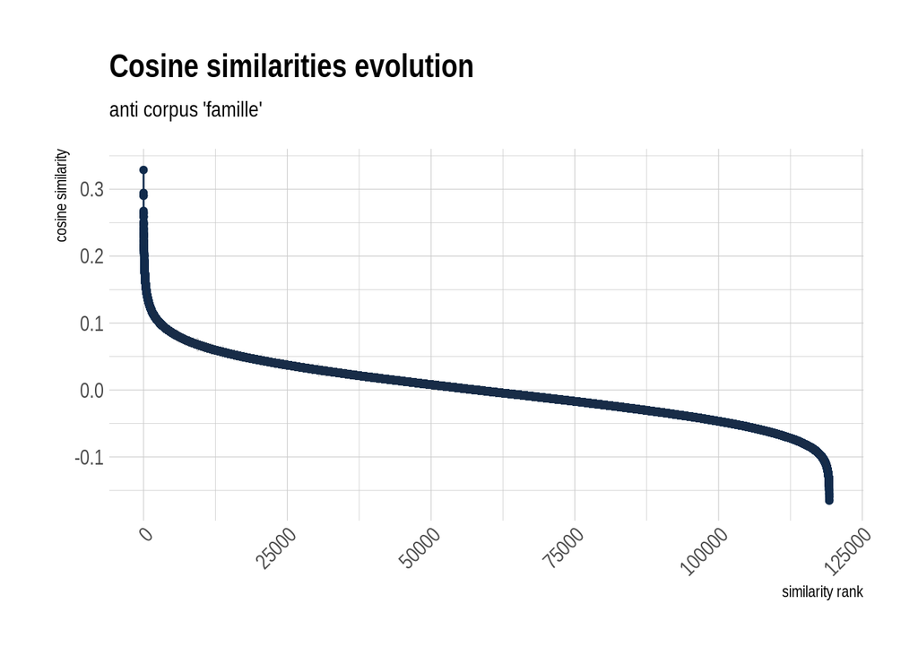

```r
# Make cosine similarity plot : famille.

#anti
df <- anti_famille.df
df$X <- factor(df$X, levels = df$X[order(-df$mean)])
df <- df %>%
  mutate(simranks = 1:n())

# The blue from the LLF logo, which we used for the antis
# in the paper
LLF_Blue <- "#112b4c"

anti_famille_cosine.plot <- ggplot(df, aes(x=simranks, y=mean)) +
  geom_point(color = LLF_Blue) +
  geom_line(aes(x = simranks, y = mean), color = LLF_Blue) +
  geom_ribbon(aes(ymin=ci95_lo, ymax=ci95_hi), alpha = 0.2) +
  labs(title = "Cosine similarities evolution",
       subtitle = "anti corpus 'famille'",
       x = "similarity rank",
       y = "cosine similarity") +
  theme_ipsum() +

  theme(axis.text.x = element_text(angle = 45, hjust = 1, vjust = 1))

anti_famille_cosine.plot
```

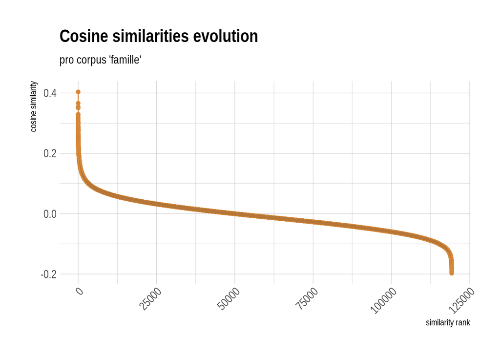

```r
#pro
df <- pro_famille.df
df$X <- factor(df$X, levels = df$X[order(-df$mean)])
df <- df %>%
  mutate(simranks = 1:n())

# The yellow from the LLF logo, which we used for the pros
# in the paper
LLF_Yellow <- "#d68738"

pro_famille_cosine.plot <- ggplot(df, aes(x=simranks, y=mean)) +
  geom_point(color = LLF_Yellow) +
  geom_line(aes(x = simranks, y = mean), color = LLF_Yellow) +
  geom_ribbon(aes(ymin=ci95_lo, ymax=ci95_hi), alpha = 0.2) +
  labs(title = "Cosine similarities evolution",
       subtitle = "pro corpus 'famille'",
       x = "similarity rank",
       y = "cosine similarity") +
  theme_ipsum() +

  theme(axis.text.x = element_text(angle = 45, hjust = 1, vjust = 1))

pro_famille_cosine.plot
```

Although there seem to be less high cosine similarity scores, the trend is, expectedly, the same.

#### CLose-up

Let’s try to look in more detail to the 100 closest words to look at the plateauing point and try to assess if it makes sense to compare words before that point.

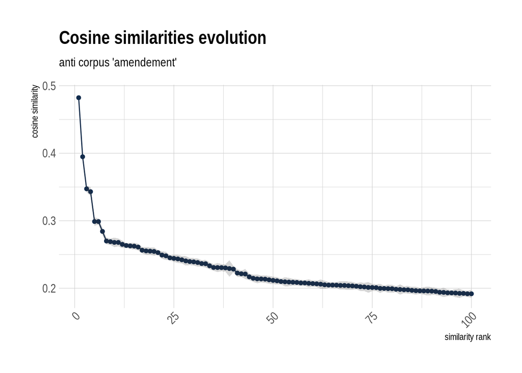

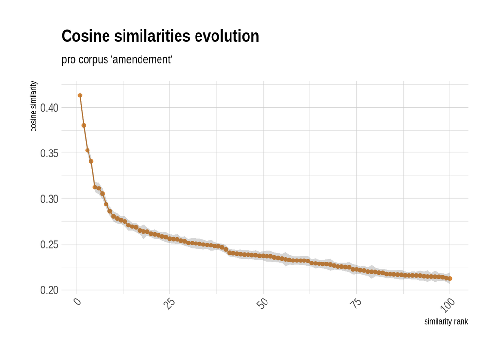

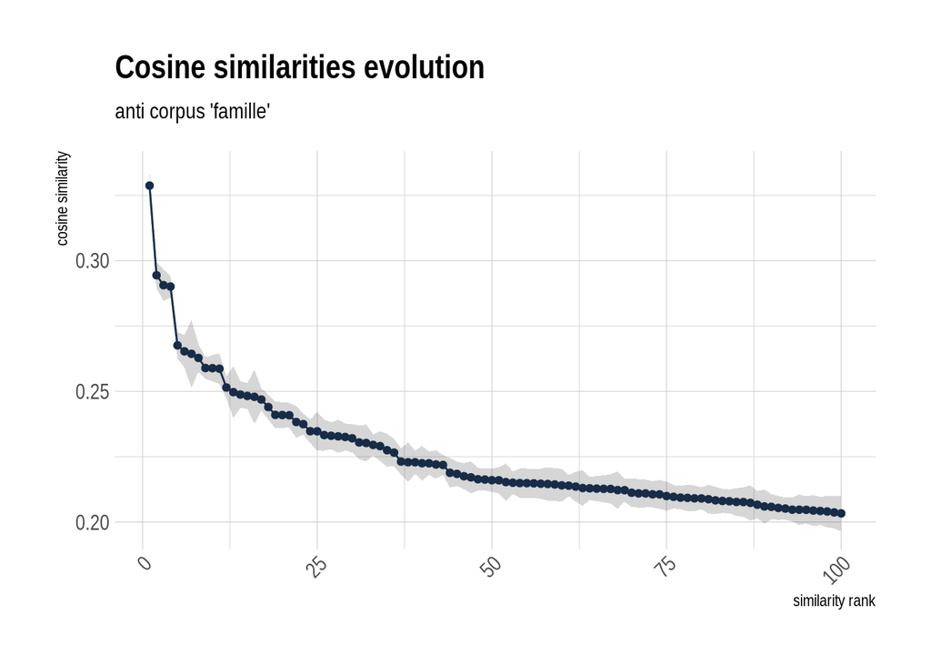

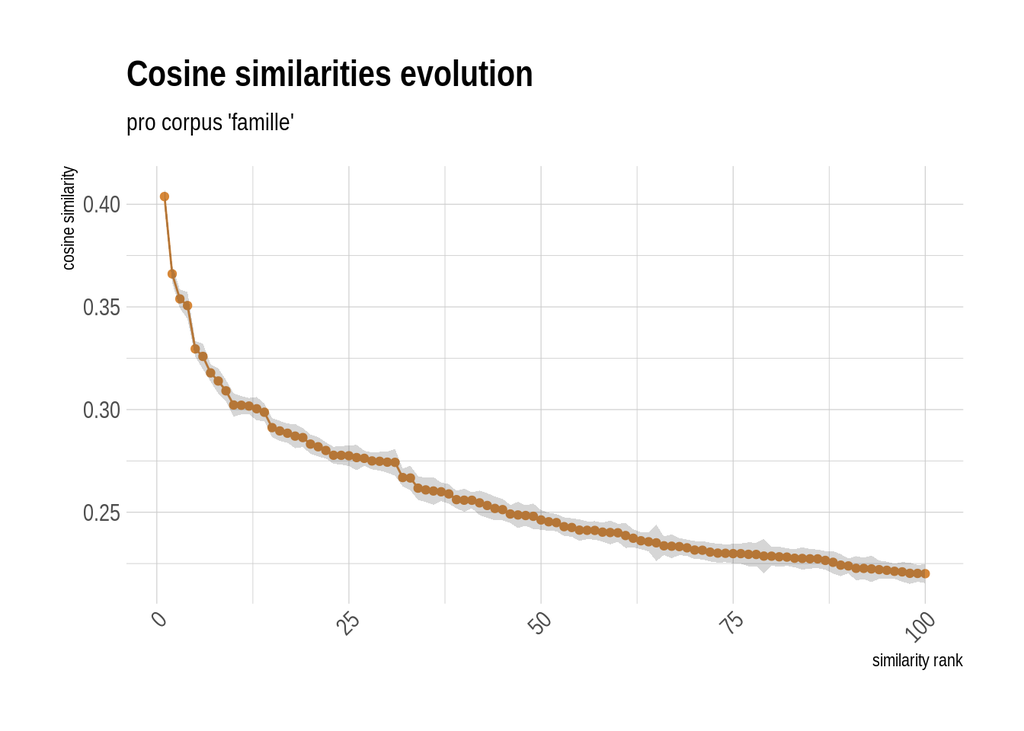

The tendency is the same all along: there tends to be small groupings of words for which the difference in ranking means very little, but beyond those groupings, it starts to have more meaning.

#### Dealing with the groupings

The size of the groupings gets larger as we progress through the ranks. One way to see if the differences between two lists of words can be trusted with rank numbers at face value could be to do the following:

- Do what we did with the ranking comparison in our comparison step.
- For each different word, instead of taking its ranking directly, we could take the rank of the word with the highest observed mean that is comprised in its 95% confidence interval.
- This would give us much more conservative measurements, but it would also give us more confidence in the fact that the differences we’re looking at are meaningful.

Let’s try this with ‘amendement’ and ‘famille’. What we need to do is rewrite the rank-finding part of our comparison function, so that instead of outputing the actual rank of the missing words, it outputs the new, conservative ranks we’ve just mentioned. Let’s first check what it does to our missing words rank list case by case, we will then implement it in the general rank comparison function, which outputs the average rank.

```r
# We make new versions of these functions taking into account the aforementioned remarks
find_highest_rank <- function(rank, df){
  # This function takes the rank of one word (ie. its row in the ordered version of a dataframe)
  # as well as its dataframe of origin and give the 'highest compatible rank', that is
  # the rank of the word that has the highest mean cosine similarity within the confidence
  # interval of the cosine similarity of the word signified by the rank provided
 interval <- c(df[rank,]$ci95_lo, df[rank,]$ci95_hi) #define the interval using 95%ci
 compatible_values <- subset(df, mean>interval[1] & mean<interval[2]) #check which words are compatible
 max_mean <- max(compatible_values$mean) #isolate the one with the highest mean cosine similarity
 max_rank <- which(max_mean == df$mean) #find which word it is in the ordered df and its rank/row
 return(max_rank)
}

# Updated find_rank function
newfind_rank <- function(missing_word, df){
    rank <- which(missing_word == df$X)
    newrank <- find_highest_rank(rank, df)
    return(newrank[1])
}

# Looking at amendement
missing_words <- unique(anti_amendement_most_similar_words[! anti_amendement_most_similar_words %in% pro_amendement_most_similar_words])
print(missing_words)
```

```
## [1] "articler"    "amendements" "alinéa"      "argument"    "motion"
## [6] "précision"   "initiative"
```

```r
print(unlist(lapply(missing_words, newfind_rank, df=pro_amendement.df)))
```

```
## [1] 41 16 14 25 27 12 28
```

```r
missing_words <- unique(pro_amendement_most_similar_words[! pro_amendement_most_similar_words %in% anti_amendement_most_similar_words])
print(missing_words)
```

```
## [1] "dispositif"  "amender"     "rapporteur"  "rectifié"    "disposition"
## [6] "accord"      "procaccia"
```

```r
print(unlist(lapply(missing_words, newfind_rank, df=anti_amendement.df)))
```

```
## [1]  12  34  31  81  12 496  59
```

```r
# Looking at famille
missing_words <- unique(anti_famille_most_similar_words[! anti_famille_most_similar_words %in% pro_famille_most_similar_words])
print(missing_words)
```

```
## [1] "société"    "filiation"  "vie"        "mère"       "parentèle"
## [6] "justice"    "solidarité" "population"
```

```r
print(unlist(lapply(missing_words, newfind_rank, df=pro_famille.df)))
```

```
## [1]  39  39  10  18  34 175  72  21
```

```r
missing_words <- unique(pro_famille_most_similar_words[! pro_famille_most_similar_words %in% anti_famille_most_similar_words])
print(missing_words)
```

```
## [1] "enfant"       "fratrie"      "parent"       "situation"    "conjugalité"
## [6] "difficulté"   "endogamie"    "déracinement"
```

```r
print(unlist(lapply(missing_words, newfind_rank, df=anti_famille.df)))
```

```
## [1] 12 23 52 23 12 85 61 38
```

As we can see, the associations do change a bit, and does so according to our intuition, meaning that words that had higher mean cosine similarity change a little bit (16 -> 14) and words which were further down change a lot more (569 -> 496) in absolute terms. In relative terms, however, it is not necessarily the case (both cases here constitute a 12% change in ranking, approximately). In any case, this makes us more confident in the meaning of our comparisons, I think.

Let’s see how the average then changes (although it should not much), comparing the places of missing anti words in pro df first:

```r
newcompare_ranks <- function(list_a, list_b, df_b){
  missing_words <- unique(list_a[! list_a %in% list_b])
  ranks_in_b <- unlist(lapply(missing_words, FUN=find_rank, df=df_b))
  newranks_in_b <- lapply(ranks_in_b, FUN=find_highest_rank, df=df_b)

  newavg_rank <- sum(as.numeric(newranks_in_b))/length(missing_words)
  return(newavg_rank)
}


comparison_amendement_anti_pro <- newcompare_ranks(anti_amendement_most_similar_words,
                                                pro_amendement_most_similar_words,
                                                pro_amendement.df)

comparison_famille_anti_pro <- newcompare_ranks(anti_famille_most_similar_words,
                                                pro_famille_most_similar_words,
                                                pro_famille.df)

print(comparison_amendement_anti_pro)
```

```
## [1] 23.28571
```

```r
print(comparison_famille_anti_pro)
```

```
## [1] 51
```

And then the other way round:

```r
comparison_amendement_pro_anti <- newcompare_ranks(pro_amendement_most_similar_words,
                                                anti_amendement_most_similar_words,
                                                anti_amendement.df)

comparison_famille_pro_anti <- newcompare_ranks(pro_famille_most_similar_words,
                                                anti_famille_most_similar_words,
                                                anti_famille.df)

print(comparison_amendement_pro_anti)
```

```
## [1] 103.5714
```

```r
print(comparison_famille_pro_anti)
```

```
## [1] 38.25
```

As we can see, the trend hasn’t changed (and is still unsatisfactory), but the numbers are lower, and I am more confident in those conservative estimates.

### Checking with other words

As mentioned before, the entire battery of tests is done in the `diff_measure.R` script, but we will still try two more words in this document in the hopes to have a more convincing case for our measure. Let’s focus on ‘hier’ and ‘mariage’. ‘hier’ is one of the control words, but it’s quite a change from ‘amendement’ because it is not part of the legislative sociolect, but a deictic, let’s see how this affects the results. As for ‘mariage’, the choice there is arbitrary.

Let’s first load and clean the data:

```r
#LOAD DATA
anti_hier.df <- read.csv("../data/anti/SANITY/hier_stats.csv", header = TRUE)
anti_mariage.df <- read.csv("../data/anti/TEST/mariage_stats.csv", header = TRUE)

pro_hier.df <- read.csv("../data/pro/SANITY/hier_stats.csv", header = TRUE)
pro_mariage.df <- read.csv("../data/pro/TEST/mariage_stats.csv", header = TRUE)
```

```r
#Sort the data using the mean to recreate the list of most similar words,
#we also get rid of the first entry; which is the word itself
#anti
anti_hier.df <- anti_hier.df[order(-anti_hier.df$mean), , drop = FALSE]
anti_hier.df <- anti_hier.df[-1,]
anti_mariage.df <- anti_mariage.df[order(-anti_mariage.df$mean), , drop = FALSE]
anti_mariage.df <- anti_mariage.df[-1,]

#pro
pro_hier.df <- pro_hier.df[order(-pro_hier.df$mean), , drop = FALSE]
pro_hier.df <- pro_hier.df[-1,]
pro_mariage.df <- pro_mariage.df[order(-pro_mariage.df$mean), , drop = FALSE]
pro_mariage.df <- pro_mariage.df[-1,]
```

```r
#anti
anti_hier_most_similar_words <- anti_hier.df$X[1:12]
anti_mariage_most_similar_words <- anti_mariage.df$X[1:12]

#pro
pro_hier_most_similar_words <- pro_hier.df$X[1:12]
pro_mariage_most_similar_words <- pro_mariage.df$X[1:12]
```

There, we have our lists of 12 most similar words. We will now do the comparison using the `newcompare_ranks` method. We will also produce similar plots to what we had before to check that the words behave in the same way.

First the average rank differences, one way then the other.

```r
comparison_hier_anti_pro <- newcompare_ranks(anti_hier_most_similar_words,
                                                pro_hier_most_similar_words,
                                                pro_hier.df)

comparison_mariage_anti_pro <- newcompare_ranks(anti_mariage_most_similar_words,
                                                pro_mariage_most_similar_words,
                                                pro_mariage.df)

print(comparison_hier_anti_pro)
```

```
## [1] 87.33333
```

```r
print(comparison_mariage_anti_pro)
```

```
## [1] 23.85714
```

```r
comparison_hier_pro_anti <- newcompare_ranks(pro_hier_most_similar_words,
                                                anti_hier_most_similar_words,
                                                anti_hier.df)

comparison_mariage_pro_anti <- newcompare_ranks(pro_mariage_most_similar_words,
                                                anti_mariage_most_similar_words,
                                                anti_mariage.df)

print(comparison_hier_pro_anti)
```

```
## [1] 20.83333
```

```r
print(comparison_mariage_pro_anti)
```

```
## [1] 35.71429
```

Then the details

```r
# Looking at hier
# Looking at the words in the anti list missing from the pro list
missing_words <- unique(anti_hier_most_similar_words[! anti_hier_most_similar_words %in% pro_hier_most_similar_words])
print(missing_words)
```

```
## [1] "samedi"      "vendredi"    "commenter"   "mercredi"    "aujourd'hui"
## [6] "sansanx"
```

```r
print(unlist(lapply(missing_words, newfind_rank, df=pro_hier.df)))
```

```
## [1] 337  69  15  41  28  34
```

```r
# ... and vice versa
missing_words <- unique(pro_hier_most_similar_words[! pro_hier_most_similar_words %in% anti_hier_most_similar_words])
print(missing_words)
```

```
## [1] "soir"      "lendemain" "promettre" "arrivé"    "jour-là"   "verdict"
```

```r
print(unlist(lapply(missing_words, newfind_rank, df=anti_hier.df)))
```

```
## [1] 12 32 17 14 25 25
```

```r
# Looking at mariage
# Looking at the words in the anti list missing from the pro list
missing_words <- unique(anti_mariage_most_similar_words[! anti_mariage_most_similar_words %in% pro_mariage_most_similar_words])
print(missing_words)
```

```
## [1] "couple"    "conjoint"  "pma"       "union"     "droit"     "motif"
## [7] "filiation"
```

```r
print(unlist(lapply(missing_words, newfind_rank, df=pro_mariage.df)))
```

```
## [1] 18 33 30 11 26 22 27
```

```r
# ... and vice versa
missing_words <- unique(pro_mariage_most_similar_words[! pro_mariage_most_similar_words %in% anti_mariage_most_similar_words])
print(missing_words)
```

```
## [1] "indissolubilité" "remariage"       "wedding"         "marier"
## [5] "état-civil"      "dragée"          "noce"
```

```r
print(unlist(lapply(missing_words, newfind_rank, df=anti_mariage.df)))
```

```
## [1] 23 50 66 45 32 18 16
```

Finally, a replication of each of the plots we already presented for ‘amendement’ and ‘famille’:

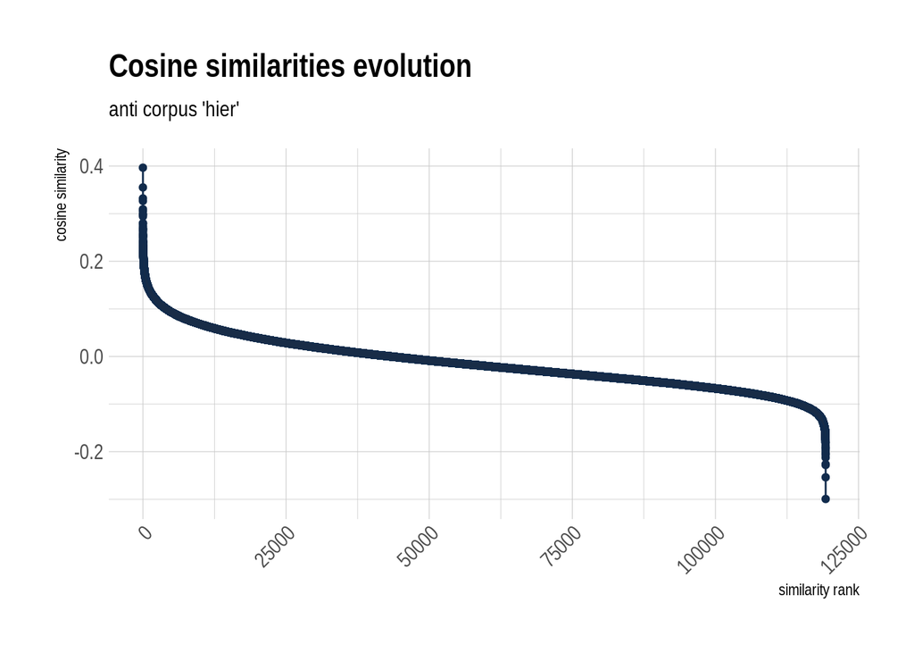

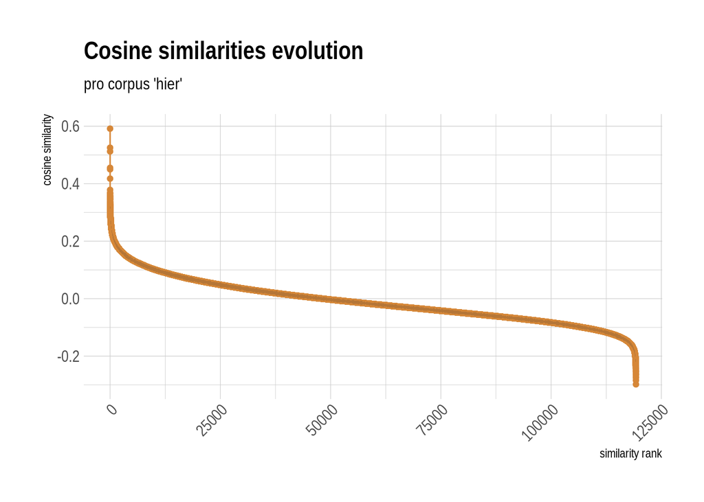

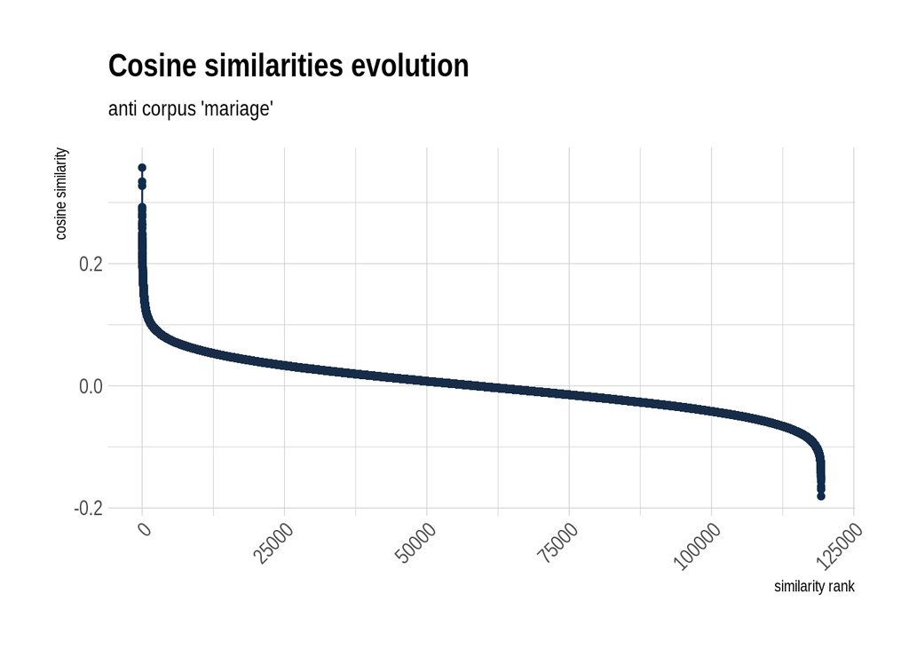

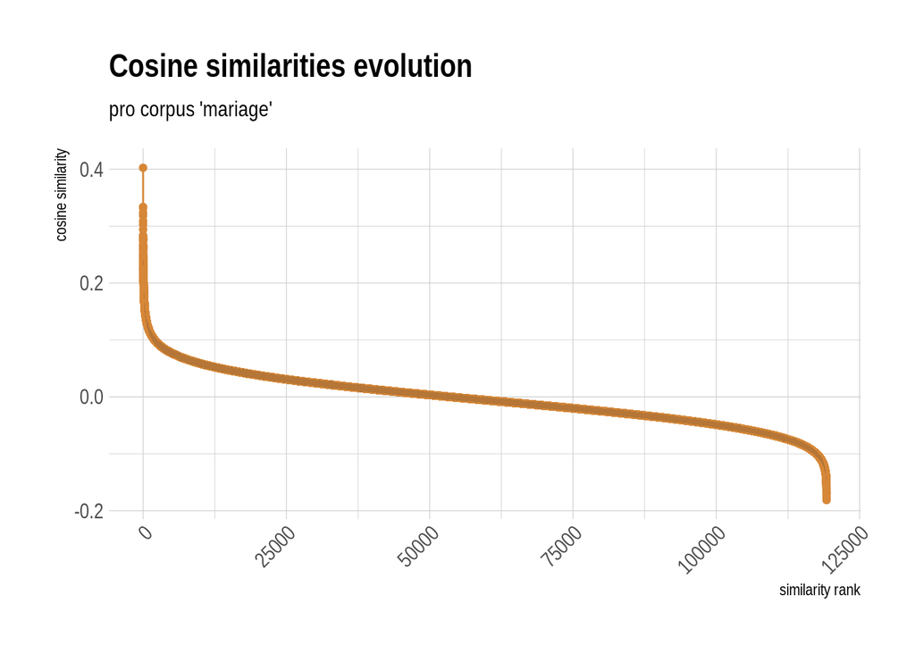

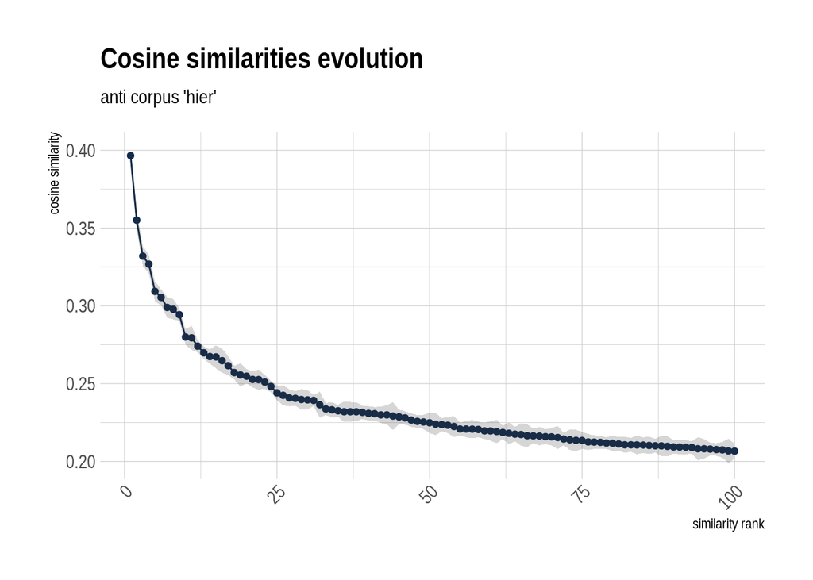

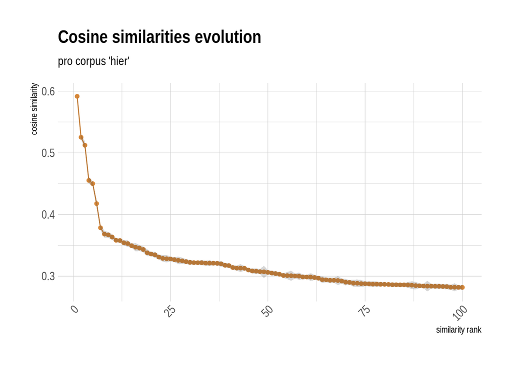

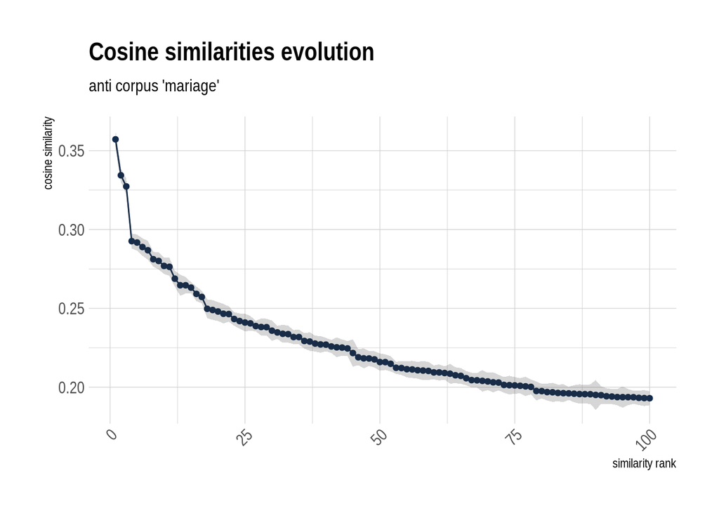

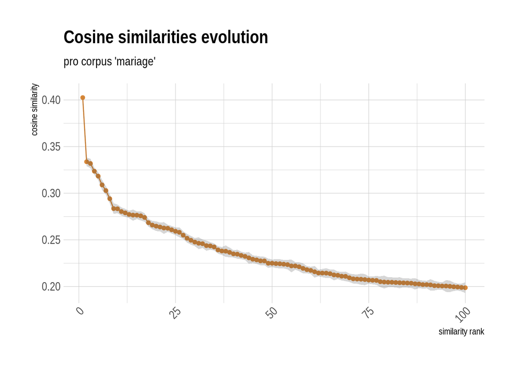

Once again, the differences observed aren’t as tell-tale as I’d hoped. Maybe this is not as good a measure after all (but it did make sense, philosophically so I’m happy I tried it). The data for all words is available in `diff_measure.R`.

# Conclusion

Turns out it doesn’t work that well, it is still unclear to me why. One possibility is just that we don’t have enough data to have interesting results after all. This would make me sad but is a possibility. I don’t really want to believe it, however; there is no more data on this subject, so saying ‘we need more data’ does not answer our problem (and it feels lazy).

Another very possible issue might be that the models I have trained are of poorer quality than I thought. This might be due to a poor choice of hyperparameters, or to poor quality of the pre-trained embeddings. Both seem possible to me (the pre-trained embeddings did have some strange stuff going on). In any case, I should perhaps try different hyperparameters, but one issue I have here is that there isn’t a lot of literature that does this kind of work, and there is in general no precision about the parameters themselves in said literature. Also, because I have no real ‘task’, therefore no real measure of ‘success’, it is not clear how I would optimize these parameters (optimize according to what?).

In any case: so far I have failed to find the systematic, quantitative solution to comparing word usege between social groups that I was looking for. But I’ll keep looking.